# Binary Searching

Pencarian dengan algoritma sequential search akan menemukan data dengan cepat jika data yang dicari terletak di indeks pertama dari suatu list data. Akan tetapi jika data yang dicari berada di posisi terakhir dari suatu list atau posisi lain, maka algoritma sequential search ini akan membutuhkan waktu yang lebih lama, karena algoritma ini akan mencari satu persatu, dimulai dari indeks pertama sampai dengan indeks terakhir.

Pada algoritma binary search pencarian tidak dilakukan satu persatu, melainkan memanfaatkan kelebihan pencarian di data yang sudah terurut.

Pada binary search, pencarian dilakukan pertama kali di indeks list yang berada ditengah. Jika data yang dicari sama dengan data pada indeks tersebut, maka pencarian berakhir. Akan tetapi jika data yang dicari lebih besar dari data yang berada di indeks tengah tersebuh, maka dilakukan pencarian lagi. Hanya saja pencarian tidak dilakukan pada seluruh data, hanya data yang berada indeks-indeks setelah indeks tengah tadi, karena data sebelum indeks tengah, pasti lebih kecil nilainya, sehingga tidak perlu dilakukan pencarian lagi. Proses ini dilakukan secara terus menerus sampai data ketemu atau tidak ada lagi data yang dapat dicari di dalam list. Oleh karena itu, binary search tidak perlu mencari di semua data pada list, sehingga waktu komputasi yang dibutuhkan lebih cepat dibandingkan dengan pencarian sequential search.

Ilustrasi pencarian binary search ini dapat dilihat pada Gambar berikut.

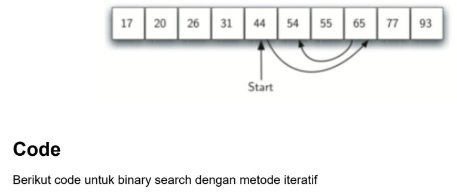

```python
def binarySearch(listData, data):
    first = 0
    last = len(listData) - 1
    found = False
    while first <= last and not found:
        midpoint = (first + last) // 2
        if listData[midpoint] == data:
            found = True
        else:
            if data < listData[midpoint]:
                last = midpoint - 1
            else:
                first = midpoint + 1
    return found

a=[4,6,10,34,56,78,99]
print(binarySearch(a,34))
```

```
True
```

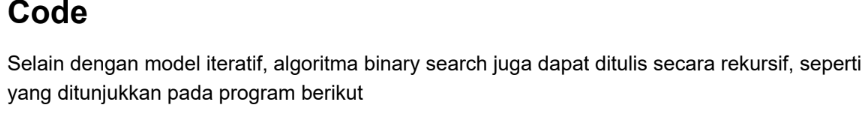

```python
def binarySearch2(listData, data):
    if len(listData) == 0:
        return False
    else:
        midpoint = len(listData) // 2
        if listData[midpoint] == data:
            return True
        else:
            if data < listData[midpoint]:
                return binarySearch2(listData[first:last+1], data)
            else:
                return binarySearch2(listData[midpoint + 1:], data)

a=[4,6,10,34,56,78,99]
binarySearch2(a,78)
```

```
True
```

```python
# binery search
def binarysearch(listd,value):
    first=0
    last=len(listd)-1

    while first<=last:
        mid=(first+last)//2
        if listd[mid]==value:
            return mid
        elif listd[mid]<value:
            first=mid+1
        else:
            last=mid-1
    return-1

data = [2, 5, 8, 12, 16, 23, 38, 56, 72, 91]
cari = 23
print(binarysearch(data,cari))
```

```
5
```

```python
# linear search
data = [2, 5, 8, 12, 16, 23, 38, 56, 72, 91]
cari = 11

first = 0
last = len(data) - 1

while first <= last:
    mid = (first + last) // 2

    if data[mid] == cari:
        print("ketemu di index", mid)
        break
    elif data[mid] < cari:
        first = mid + 1
    else:
        last = mid - 1
```

```python
def linearSearch(data, key):
  iterasi=0
  for i in range(len(data)):
    iterasi+=1
    if data[i]==key:
      return i, iterasi

  return -1, iterasi

def terdekat(data,key):
  selisih_kecil=1000
  dekat=[]
  for i in data:
    selisih=i-key
    if selisih<0:
      selisih=-selisih

    if selisih < selisih_kecil:
      selisih_kecil = selisih
      dekat = [i]
    elif selisih == selisih_kecil:
      dekat.append(i)

  return dekat

data = [10, 20, 30, 40, 50]
key = 35

index,iterasi = linearSearch(data, key)
if index != -1:
    print("Data ditemukan pada index ke-", index)
else:
    print("Data tidak ditemukan")
    dekat = terdekat(data, key)
    print("Nilai terdekat :", end=" ")
    for i in range(len(dekat)):
        if i == len(dekat)-1:
            print(dekat[i])
        else:
            print(dekat[i], "dan", end=" ")
```

```
Data tidak ditemukan
Nilai terdekat : 30 dan 40
```

```python
def linear(data,lower,upper):
  hasil=[]
  iterasi=0
  for i in range(len(data)):
    iterasi+=1
    if data[i] >=lower and data[i] <=upper:
      hasil.append(data[i])

  return hasil, iterasi

def binary_search(data,lower,upper):
  hasil=[]
  iterasi=0

  data.sort()

  awal=0
  akhir=len(data)-1
  while awal<akhir:
    iterasi+=1
    tengah=(awal+akhir)//2
    if data[tengah]<lower:
      awal=tengah+1
    else:
      akhir=tengah-1

  index=awal
  while index<len(data):
    if data[index]>upper:
      break

    iterasi+=1
    hasil.append(data[index])
    index+=1

  return data, hasil, iterasi

data=[5,1,8,12,3,20,15]
lower=5
upper=15

hasilLinear, iterasiLinear = linear(data, lower, upper)
print("HASIL LINEAR SEARCH (Unordered)")
print("Data dalam range :", hasilLinear)
print("Jumlah iterasi :", iterasiLinear)

print()

dataUrut, hasilBinary, iterasiBinary = binary_search(data, lower, upper)
print("HASIL BINARY SEARCH")
print("Data terurut :", dataUrut)
print("Data dalam range :", hasilBinary)
print("Jumlah iterasi :", iterasiBinary)
```

```
HASIL LINEAR SEARCH (Unordered)
Data dalam range : [5, 8, 12, 15]
Jumlah iterasi : 7

HASIL BINARY SEARCH
Data terurut : [1, 3, 5, 8, 12, 15, 20]
Data dalam range : [5, 8, 12, 15]
Jumlah iterasi : 6
```